# Ford GoBike 2017-2018-2019

## Preliminary Wrangling

> This document explore Ford GoBike System data for the years 2017/18/19.

```python
# import all packages and set plots to be embedded inline
import numpy as np
import pandas as pd
import matplotlib.pyplot as plt
import seaborn as sb
import os
import glob
%matplotlib inline
```

```python
# 2017 data
df_17=pd.read_csv('/Users/mamaal3sl/Downloads/Project Template/2017-fordgobike-tripdata.csv')
```

```python
# 2018 data, here each month was in a seperate csv file and i made it in one file

os.chdir("/Users/mamaal3sl/Downloads/Project Template/2018bike")
extension = 'csv'
all_filenames = [i for i in glob.glob('*.{}'.format(extension))]
#combine all files in the list
combined_csv = pd.concat([pd.read_csv(f) for f in all_filenames ])
#export to csv
combined_csv.to_csv( "combined_2018.csv", index=False, encoding='utf-8-sig')

#reff. (https://www.freecodecamp.org/news/how-to-combine-multiple-csv-files-with-8-lines-of-code-265183e0854/)
```

```python
# 2019 data, here each month was in a seperate csv file and i made it in one file

os.chdir("/Users/mamaal3sl/Downloads/Project Template/2019bike")
extension = 'csv'
all_filenames = [i for i in glob.glob('*.{}'.format(extension))]
#combine all files in the list
combined_csv = pd.concat([pd.read_csv(f) for f in all_filenames ])
#export to csv
combined_csv.to_csv( "combined_2019.csv", index=False, encoding='utf-8-sig')

#reff. (https://www.freecodecamp.org/news/how-to-combine-multiple-csv-files-with-8-lines-of-code-265183e0854/)
```

```python
df_17.head()
```

[output not shown]

```python
df_18=pd.read_csv('/Users/mamaal3sl/Downloads/Project Template/2018bike/combined_2018.csv')
df_18.head()
```

|  | duration_sec | start_time | end_time | start_station_id | start_station_name | start_station_latitude | start_station_longitude | end_station_id | end_station_name | end_station_latitude | end_station_longitude | bike_id | user_type | bike_share_for_all_trip |
| --- | --- | --- | --- | --- | --- | --- | --- | --- | --- | --- | --- | --- | --- | --- |
| 0 | 598 | 2018-02-28 23:59:47.0970 | 2018-03-01 00:09:45.1870 | 284.0 | Yerba Buena Center for the Arts (Howard St at ... | 37.784872 | -122.400876 | 114.0 | Rhode Island St at 17th St | 37.764478 | -122.402570 | 1035 | Subscriber | No |
| 1 | 943 | 2018-02-28 23:21:16.4950 | 2018-02-28 23:36:59.9740 | 6.0 | The Embarcadero at Sansome St | 37.804770 | -122.403234 | 324.0 | Union Square (Powell St at Post St) | 37.788300 | -122.408531 | 1673 | Customer | No |
| 2 | 18587 | 2018-02-28 18:20:55.1900 | 2018-02-28 23:30:42.9250 | 93.0 | 4th St at Mission Bay Blvd S | 37.770407 | -122.391198 | 15.0 | San Francisco Ferry Building (Harry Bridges Pl... | 37.795392 | -122.394203 | 3498 | Customer | No |
| 3 | 18558 | 2018-02-28 18:20:53.6210 | 2018-02-28 23:30:12.4500 | 93.0 | 4th St at Mission Bay Blvd S | 37.770407 | -122.391198 | 15.0 | San Francisco Ferry Building (Harry Bridges Pl... | 37.795392 | -122.394203 | 3129 | Customer | No |
| 4 | 885 | 2018-02-28 23:15:12.8580 | 2018-02-28 23:29:58.6080 | 308.0 | San Pedro Square | 37.336802 | -121.894090 | 297.0 | Locust St at Grant St | 37.322980 | -121.887931 | 1839 | Subscriber | Yes |

```python
df_19=pd.read_csv('/Users/mamaal3sl/Downloads/Project Template/2019bike/combined_2019.csv')
df_19.head()
```

|  | bike_id | bike_share_for_all_trip | duration_sec | end_station_id | end_station_latitude | end_station_longitude | end_station_name | end_time | rental_access_method | start_station_id | start_station_latitude | start_station_longitude | start_station_name | start_time | user_type |
| --- | --- | --- | --- | --- | --- | --- | --- | --- | --- | --- | --- | --- | --- | --- | --- |
| 0 | 12904 | No | 60863 | 465.0 | 37.776329 | -122.394438 | San Francisco Caltrain Station (King St at 4th... | 2019-10-01 04:42:25.8640 | NaN | 465.0 | 37.776329 | -122.394438 | San Francisco Caltrain Station (King St at 4th... | 2019-09-30 11:48:02.7100 | Customer |
| 1 | 163 | No | 36019 | 443.0 | 37.320866 | -121.876279 | 3rd St at Keyes St | 2019-10-01 02:16:51.9820 | NaN | 294.0 | 37.327581 | -121.884559 | Pierce Ave at Market St | 2019-09-30 16:16:32.3530 | Customer |
| 2 | 10737 | No | 5615 | 4.0 | 37.785881 | -122.408915 | Cyril Magnin St at Ellis St | 2019-10-01 00:46:01.9590 | NaN | 370.0 | 37.787327 | -122.413278 | Jones St at Post St | 2019-09-30 23:12:25.9980 | Customer |
| 3 | 10346 | No | 1482 | 460.0 | 37.769095 | -122.386333 | Terry Francois Blvd at Warriors Way | 2019-10-01 00:22:16.8490 | NaN | 109.0 | 37.763316 | -122.421904 | 17th St at Valencia St | 2019-09-30 23:57:34.6630 | Customer |
| 4 | 1349 | No | 1272 | 127.0 | 37.756708 | -122.421025 | Valencia St at 21st St | 2019-10-01 00:14:41.0740 | NaN | 95.0 | 37.766219 | -122.431060 | Sanchez St at 15th St | 2019-09-30 23:53:28.6530 | Subscriber |

```python
print(df_17.shape)
print(df_17.dtypes)
```

[output not shown]

```python
print(df_18.shape)
print(df_18.dtypes)
```

```
(1863721, 14)
duration_sec                 int64
start_time                  object
end_time                    object
start_station_id           float64
start_station_name          object
start_station_latitude     float64
start_station_longitude    float64
end_station_id             float64
end_station_name            object
end_station_latitude       float64
end_station_longitude      float64
bike_id                      int64
user_type                   object
bike_share_for_all_trip     object
dtype: object
```

```python
print(df_19.shape)
print(df_19.dtypes)
```

```
(2506983, 15)
bike_id                      int64
bike_share_for_all_trip     object
duration_sec                 int64
end_station_id             float64
end_station_latitude       float64
end_station_longitude      float64
end_station_name            object
end_time                    object
rental_access_method        object
start_station_id           float64
start_station_latitude     float64
start_station_longitude    float64
start_station_name          object
start_time                  object
user_type                   object
dtype: object
```

```python
print(df_17.duplicated().sum())
print(df_18.duplicated().sum())
print(df_19.duplicated().sum())
```

```
0
0
0
```

```python
#changing data type from object to date and time format
df_19.end_time=pd.to_datetime(df_19.end_time)
df_19.start_time=pd.to_datetime(df_19.start_time)
```

```python
df_18.end_time=pd.to_datetime(df_18.end_time)
df_18.start_time=pd.to_datetime(df_18.start_time)
```

```python
df_17.end_time=pd.to_datetime(df_17.end_time)
df_17.start_time=pd.to_datetime(df_17.start_time)
```

```python
#changing data type from intger to string
df_19.bike_id=df_19.bike_id.astype(str)
df_19.start_station_id=df_19.start_station_id.astype(str)
df_19.end_station_id=df_19.end_station_id.astype(str)
```

```python
df_18.bike_id=df_18.bike_id.astype(str)
df_18.start_station_id=df_18.start_station_id.astype(str)
df_18.end_station_id=df_18.end_station_id.astype(str)
```

```python
df_17.bike_id=df_17.bike_id.astype(str)
df_17.start_station_id=df_17.start_station_id.astype(str)
df_17.end_station_id=df_17.end_station_id.astype(str)
```

```python
# here am separating the month from the starting date column
df_17['month'] = df_17['start_time'].dt.month
df_18['month'] = df_18['start_time'].dt.month
df_19['month'] = df_19['start_time'].dt.month
#reff https://stackoverflow.com/questions/25146121/extracting-just-month-and-year-separately-from-pandas-datetime-column
```

```python
print(df_19.month.value_counts())
print(df_18.month.value_counts())
print(df_17.month.value_counts()) #here we have the recordes of 7 months only
```

```
7     258102
3     256299
10    239895
4     239111
9     217986
8     210563
1     192082
6     191772
11    185496
2     183412
5     182163
12    150102
Name: month, dtype: int64
10    201458
7     199222
```

[output cut: 19 more lines]

```python
# here am separating the day from the starting date column
df_17['start_day'] = df_17['start_time'].dt.strftime('%A')
df_18['start_day'] = df_18['start_time'].dt.strftime('%A')
df_19['start_day'] = df_19['start_time'].dt.strftime('%A')
#reff https://stackoverflow.com/questions/9847213/how-do-i-get-the-day-of-week-given-a-date
```

```python
df_17.sample(5)  #to check the new columns 'start_day' and 'month'
```

[output not shown]

```python
# Here converting trip duration unit from sec to min for easier interpretation
df_17['duration_min'] = df_17['duration_sec']/60
df_18['duration_min'] = df_18['duration_sec']/60
df_19['duration_min'] = df_19['duration_sec']/60
```

```python
df_19.head(2) #to check the new column 'duration_min'
```

[output not shown]

```python
print(df_17.start_day.value_counts())
print(df_18.start_day.value_counts())
print(df_19.start_day.value_counts())
```

```
Tuesday      87865
Wednesday    87752
Thursday     85243
Monday       81410
Friday       81165
Saturday     50874
Sunday       45391
Name: start_day, dtype: int64
Tuesday      319332
Wednesday    316374
Thursday     314124
Monday       294573
Friday       290390
Saturday     175614
Sunday       153314
Name: start_day, dtype: int64
Tuesday      427640
Thursday     424474
Wednesday    414448
Friday       397284
Monday       396463
Saturday     234370
Sunday       212304
Name: start_day, dtype: int64
```

```python
print (df_17.describe())
```

```
        duration_sec  start_station_latitude  start_station_longitude  \
count  519700.000000           519700.000000            519700.000000
mean     1099.009521               37.771653              -122.363927
std      3444.146451                0.086305                 0.105573
min        61.000000               37.317298              -122.444293
25%       382.000000               37.773492              -122.411726
50%       596.000000               37.783521              -122.398870
75%       938.000000               37.795392              -122.391034
max     86369.000000               37.880222              -121.874119

       end_station_latitude  end_station_longitude
count         519700.000000          519700.000000
mean              37.771844            -122.363236
std                0.086224               0.105122
min               37.317298            -122.444293
25%               37.774520            -122.410345
50%               37.783830            -122.398525
75%               37.795392            -122.391034
max               37.880222            -121.874119
```

```python
print (df_18.describe())
```

```
       duration_sec  start_station_latitude  start_station_longitude  \
count  1.863721e+06            1.863721e+06             1.863721e+06
mean   8.573026e+02            3.776678e+01            -1.223492e+02
std    2.370379e+03            1.057689e-01             1.654634e-01
min    6.100000e+01            3.726331e+01            -1.224737e+02
25%    3.500000e+02            3.777106e+01            -1.224114e+02
50%    5.560000e+02            3.778107e+01            -1.223974e+02
75%    8.720000e+02            3.779625e+01            -1.222865e+02
max    8.636600e+04            4.551000e+01            -7.357000e+01

       end_station_latitude  end_station_longitude
count          1.863721e+06           1.863721e+06
mean           3.776690e+01          -1.223487e+02
std            1.056483e-01           1.650597e-01
min            3.726331e+01          -1.224737e+02
25%            3.777106e+01          -1.224094e+02
50%            3.778127e+01          -1.223971e+02
75%            3.779728e+01          -1.222894e+02
max            4.551000e+01          -7.357000e+01
```

```python
print (df_19.describe())
```

```
       duration_sec  end_station_latitude  end_station_longitude  \
count  2.506983e+06          2.506983e+06           2.506983e+06
mean   8.076483e+02          3.776422e+01          -1.223459e+02
std    1.974714e+03          2.392885e-01           7.080417e-01
min    6.000000e+01          0.000000e+00          -1.225143e+02
25%    3.590000e+02          3.777003e+01          -1.224117e+02
50%    5.710000e+02          3.778076e+01          -1.223981e+02
75%    8.870000e+02          3.779587e+01          -1.222934e+02
max    9.121100e+05          4.551000e+01           0.000000e+00

       start_station_latitude  start_station_longitude
count            2.506983e+06             2.506983e+06
mean             3.776506e+01            -1.223499e+02
std              1.363698e-01             3.089648e-01
min              0.000000e+00            -1.225143e+02
25%              3.776931e+01            -1.224130e+02
50%              3.778053e+01            -1.223983e+02
75%              3.779539e+01            -1.222914e+02
max              4.551000e+01             0.000000e+00
```

```python
df_17.to_csv("df_17_clean.csv", index=False)
df_18.to_csv("df_18_clean.csv", index=False)
df_19.to_csv("df_19_clean.csv", index=False)
```

### What is the structure of your dataset?

> - here i am working with data from three consecutive yeas 2017, 2018 and 2019 seperated in three files. all files have common columns which is: bike_id  
>   duration_sec  
>   end_station_id  
>   end_station_latitude  
>   end_station_longitude  
>   end_station_name  
>   end_time  
>   start_station_id  
>   start_station_latitude  
>   start_station_longitude  
>   start_station_name  
>   start_time  
>   user_type(Subscriber or Customer – “Subscriber” = Member or “Customer” = Casual)
> - for 2017 recoreds, there are 519700 clints, 1863721 in 2018 and 2506983 in 2019.

### What is/are the main feature(s) of interest in your dataset?

> the features of interests are the ones related to the duration of trips, start trip stations, am also interested in kowing the user type Subscriber or Customer and its relation to other features like trip duration and at what time in term of day, week and months. in addition, is there a most frequent station used by users.

### What features in the dataset do you think will help support your investigation into your feature(s) of interest?

> From the dataset i will use in this analysis duration_sec, start_time, user_type, start_station_name.

## 1- Numbers of users per month

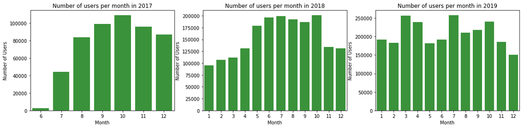

```python
plt.figure(figsize = [19, 4])

plt.subplot(1,3,1)
base_color=sb.color_palette()[2]
sb.countplot(data=df_17, x='month', color=base_color)
plt.xlabel('Month')
plt.ylabel('Number of Users')
plt.title('Number of users per month in 2017')


plt.subplot(1,3,2)
base_color=sb.color_palette()[2]
sb.countplot(data=df_18, x='month', color=base_color)
plt.xlabel('Month')
plt.ylabel('Number of Users')
plt.title('Number of users per month in 2018')

plt.subplot(1,3,3)
base_color=sb.color_palette()[2]
sb.countplot(data=df_19, x='month', color=base_color)
plt.xlabel('Month')
plt.ylabel('Number of Users')
plt.title('Number of users per month in 2019');
```

Here is a bar chart showing the number of users per month in each year. the year 2019 has the highest number of clints of almost 250000 in March and July. In 2018, October had the highest number of clints of 200000. in 2017, its clear that the data start from June with October having the highest number of counts. in all three years, there are no trends or common months where it shows increases or decreases in bike raiders in the numbers of three years.

## 2-Numbers of users per day

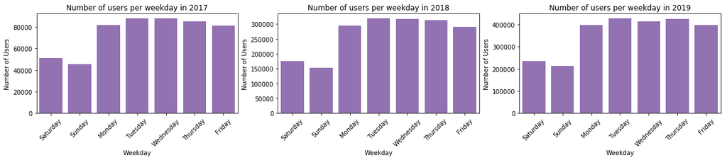

```python
plt.figure(figsize = [20, 3])

day_order=["Saturday", "Sunday", "Monday", "Tuesday", "Wednesday", "Thursday", "Friday"]
plt.subplot(1,3,1)
base_color=sb.color_palette()[4]
sb.countplot(data=df_17, x='start_day', color=base_color, order=day_order)
plt.xlabel('Weekday')
plt.ylabel('Number of Users')
plt.title('Number of users per weekday in 2017')
plt.xticks(rotation=45)


plt.subplot(1,3,2)
base_color=sb.color_palette()[4]
sb.countplot(data=df_18, x='start_day', color=base_color, order=day_order)
plt.xlabel('Weekday')
plt.ylabel('Number of Users')
plt.title('Number of users per weekday in 2018')
plt.xticks(rotation=45)


plt.subplot(1,3,3)
base_color=sb.color_palette()[4]
sb.countplot(data=df_19, x='start_day', color=base_color, order=day_order)
plt.xlabel('Weekday')
plt.ylabel('Number of Users')
plt.title('Number of users per weekday in 2019')
plt.xticks(rotation=45);
```

here I am plotted the number of bike users across weekdays, it is noteced that the number of users decreases on weekend (Sunday, Saturday). the rest of the days have almost the same number of users compared to weekend. this is applied to all three years.

## 3-The common stations in the city to start the trips

### Is there certain stations that have high number of bike users then other station

```python
top_10_station_17=df_17['start_station_name'].value_counts()[:10]
top_10_station_17
```

```
San Francisco Ferry Building (Harry Bridges Plaza)           15187
The Embarcadero at Sansome St                                13664
San Francisco Caltrain (Townsend St at 4th St)               12546
San Francisco Caltrain Station 2  (Townsend St at 4th St)    12055
Market St at 10th St                                         11960
Montgomery St BART Station (Market St at 2nd St)             11334
Berry St at 4th St                                           10956
Powell St BART Station (Market St at 4th St)                 10142
Howard St at Beale St                                         9926
Steuart St at Market St                                       9347
Name: start_station_name, dtype: int64
```

```python
top_10_station_18=(df_18['start_station_name'].value_counts())[:10]
top_10_station_18
```

```
San Francisco Ferry Building (Harry Bridges Plaza)           38461
San Francisco Caltrain Station 2  (Townsend St at 4th St)    37617
San Francisco Caltrain (Townsend St at 4th St)               35092
Market St at 10th St                                         34918
Berry St at 4th St                                           33716
The Embarcadero at Sansome St                                33390
Montgomery St BART Station (Market St at 2nd St)             32131
Powell St BART Station (Market St at 4th St)                 31656
Steuart St at Market St                                      28367
Howard St at Beale St                                        26535
Name: start_station_name, dtype: int64
```

```python
top_10_station_19=(df_19['start_station_name'].value_counts())[:10]
top_10_station_19
```

```
Market St at 10th St                                         45058
Berry St at 4th St                                           42962
San Francisco Caltrain (Townsend St at 4th St)               40302
San Francisco Ferry Building (Harry Bridges Plaza)           39016
San Francisco Caltrain Station 2  (Townsend St at 4th St)    36576
Montgomery St BART Station (Market St at 2nd St)             36081
Powell St BART Station (Market St at 4th St)                 34253
Steuart St at Market St                                      32448
Howard St at Beale St                                        31341
Powell St BART Station (Market St at 5th St)                 30581
Name: start_station_name, dtype: int64
```

```python
print(len(df_19['start_station_name'].value_counts()))
print(len(df_18['start_station_name'].value_counts()))
print(len(df_17['start_station_name'].value_counts()))
```

```
446
348
272
```

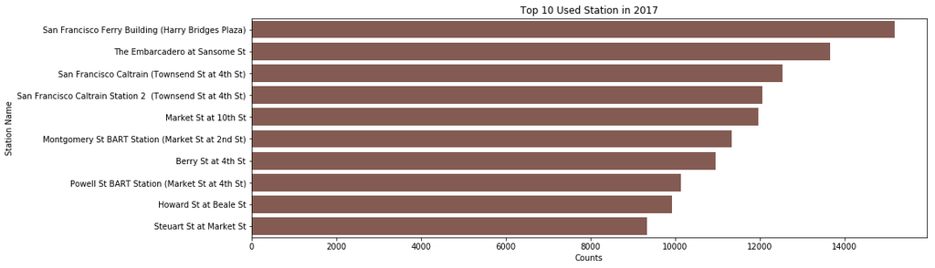

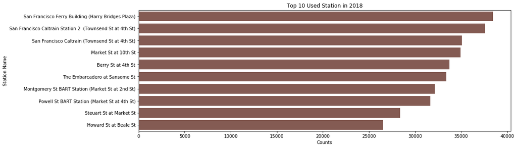

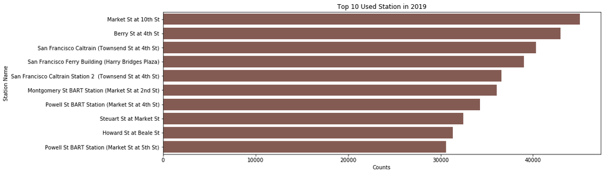

```python
plt.figure(figsize = [20, 3])


station_order=top_10_station_17.index
base_color=sb.color_palette()[5]
plt.figure(figsize = [15, 5])
sb.countplot(data=df_17, y='start_station_name', order=station_order, color=base_color)
plt.ylabel('Station Name')
plt.xlabel('Counts')
plt.title('Top 10 Used Station in 2017')



station_order=top_10_station_18.index
base_color=sb.color_palette()[5]
plt.figure(figsize = [15, 5])
sb.countplot(data=df_18, y='start_station_name', order=station_order, color=base_color)
plt.ylabel('Station Name')
plt.xlabel('Counts')
plt.title('Top 10 Used Station in 2018')



station_order=top_10_station_19.index
base_color=sb.color_palette()[5]
plt.figure(figsize = [15, 5])
sb.countplot(data=df_19, y='start_station_name', order=station_order, color=base_color)
plt.ylabel('Station Name')
plt.xlabel('Counts')
plt.title('Top 10 Used Station in 2019');
```

- San Francisco Caltrain (Townsend St at 4th St),
- San Francisco Caltrain Station 2 (Townsend St at 4th St),
- Market St at 10th St,
- Berry St at 4th St,
- Montgomery St BART Station (Market St at 2nd St),
- Powell St BART Station (Market St at 4th St),
- Howard St at Beale St,
- Steuart St at Market St

## 4-Number of users subscribers vs Customer

```python
print(df_17['user_type'].value_counts())
print(df_18['user_type'].value_counts())
print(df_19['user_type'].value_counts())
```

```
Subscriber    409230
Customer      110470
Name: user_type, dtype: int64
Subscriber    1583554
Customer       280167
Name: user_type, dtype: int64
Subscriber    2021166
Customer       485817
Name: user_type, dtype: int64
```

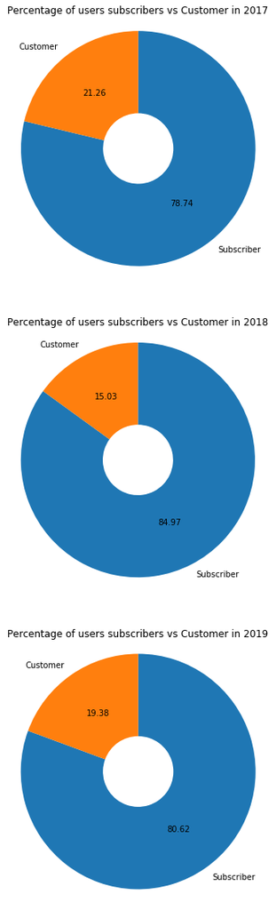

```python
plt.figure(figsize = [20, 20])

plt.subplot(3,1,1)
user_type_17 = df_17['user_type'].value_counts()
plt.pie(user_type_17, labels = user_type_17.index, startangle = 90,
        counterclock = False, wedgeprops = {'width' : 0.7}, autopct='%.2f');
plt.axis('square')
plt.title('Percentage of users subscribers vs Customer in 2017');

plt.subplot(3,1,2)
user_type_18 = df_18['user_type'].value_counts()
plt.pie(user_type_18, labels = user_type_18.index, startangle = 90,
        counterclock = False, wedgeprops = {'width' : 0.7}, autopct='%.2f');
plt.axis('square')
plt.title('Percentage of users subscribers vs Customer in 2018');

plt.subplot(3,1,3)
user_type_19 = df_19['user_type'].value_counts()
plt.pie(user_type_19, labels = user_type_19.index, startangle = 90,
        counterclock = False, wedgeprops = {'width' : 0.7}, autopct='%.2f');
plt.axis('square')
plt.title('Percentage of users subscribers vs Customer in 2019');
```

In these pie charts, we can see that the subscriber users are always in higher percentages than customers how do not have a membership in Ford GoBike. a large percentage ranging from 79 to 85% of users in the three years are users with membership. more investigation should be done to see the type of trip, duration and what of the day or week or month per user type.

### Discuss the distribution(s) of your variable(s) of interest. Were there any unusual points? Did you need to perform any transformations?

> data wrangiling and cleaning was performed befor visualization, here i have used data of three years. 2017 data have records of 7 months only started from June while 2018/19 has the records of 12 months. trip starting station was investegated and ranked to find the top 10 used station. Trip counts per day day/ months were investegated finding that trip counts decrease in weekend while no sepecific months had increase or decrease in all years( no trend). Regarding user types, the percentage of user types were investegated finding thet we have high number of subscribers compared to customers.

### Of the features you investigated, were there any unusual distributions? Did you perform any operations on the data to tidy, adjust, or change the form of the data? If so, why did you do this?

> Here converting trip duration unit from sec to min for easier interpretation. date formate was change to datetime. also, bike_id was changed to string. The day and months were seperated in different columns for better and more focused visualization.

## Bivariate Exploration

> In this section, investigate relationships between pairs of variables in your data. Make sure the variables that you cover here have been introduced in some fashion in the previous section (univariate exploration).

## 5-Trip duration vs user type

```python
duration_type_17=df_17.groupby('user_type')['duration_min'].mean()
duration_type_18=df_18.groupby('user_type')['duration_min'].mean()
duration_type_19=df_19.groupby('user_type')['duration_min'].mean()
```

```python
print(duration_type_17)
print(duration_type_18)
print(duration_type_19)
```

```
user_type
Customer      42.624096
Subscriber    11.755175
Name: duration_min, dtype: float64
user_type
Customer      32.046325
Subscriber    11.146588
Name: duration_min, dtype: float64
user_type
Customer      22.577449
Subscriber    11.269486
Name: duration_min, dtype: float64
```

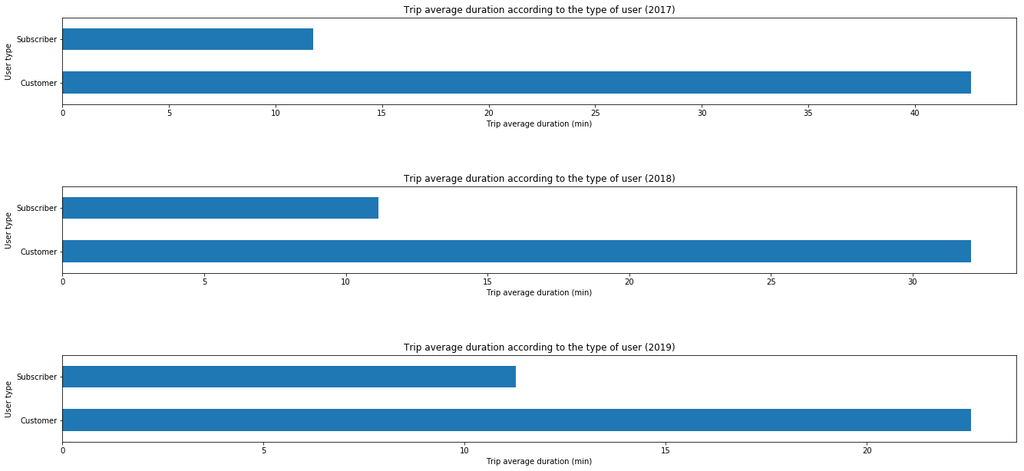

```python
plt.figure(figsize = [20, 10])


plt.subplot(3,1,1)
duration_type_17.plot.barh(x='user_type', y='duration_min')
plt.xlabel('Trip average duration (min)')
plt.ylabel('User type')
plt.title('Trip average duration according to the type of user (2017)')

plt.subplot(3,1,2)
duration_type_18.plot.barh(x='user_type', y='duration_min')
plt.xlabel('Trip average duration (min)')
plt.ylabel('User type')
plt.title('Trip average duration according to the type of user (2018)')

plt.subplot(3,1,3)
duration_type_19.plot.barh(x='user_type', y='duration_min')
plt.xlabel('Trip average duration (min)')
plt.ylabel('User type')
plt.title('Trip average duration according to the type of user (2019)')
plt.tight_layout(pad=6.0)
```

these bar chart shows Trip duration for each type of users (Subscriber vs Customer). in the years 17,18 and 19 have almost the same trend or destribution wheres the customurs tend to have longer bike trips than the subscriber how tend to use bikes for less time 11 min while 22-42 min for the Customers.

## 6-User type count during the year

```python
month_type_17=df_17.groupby(["month","user_type"]).size().reset_index()
month_type_18=df_18.groupby(["month","user_type"]).size().reset_index()
month_type_19=df_19.groupby(["month","user_type"]).size().reset_index()
```

```python
month_type_17.head(2)
```

|  | month | user_type | 0 |
| --- | --- | --- | --- |
| 0 | 6 | Customer | 450 |
| 1 | 6 | Subscriber | 2239 |

```
Text(0.5,1,'number of trips per user in 2019')
```

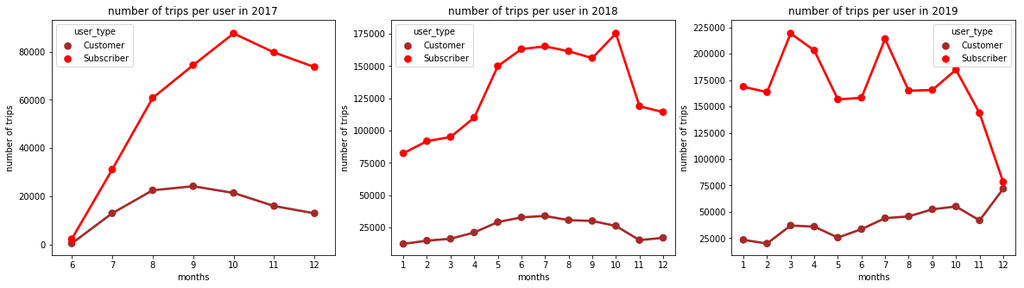

```python
plt.figure(figsize = [20, 5])

plt.subplot(1,3,1)
colors = {'Subscriber':'Red', 'Customer':'brown'}
sb.pointplot(x='month', y=0, hue='user_type', scale=.99, palette=colors, data=month_type_17)
plt.ylabel('number of trips')
plt.xlabel('months')
plt.title('number of trips per user in 2017')

plt.subplot(1,3,2)
colors = {'Subscriber':'Red', 'Customer':'brown'}
sb.pointplot(x='month', y=0, hue='user_type', scale=.99, palette=colors, data=month_type_18)
plt.ylabel('number of trips')
plt.xlabel('months')
plt.title('number of trips per user in 2018')

plt.subplot(1,3,3)
colors = {'Subscriber':'Red', 'Customer':'brown'}
sb.pointplot(x='month', y=0, hue='user_type', scale=.99, palette=colors, data=month_type_19)
plt.ylabel('number of trips')
plt.xlabel('months')
plt.title('number of trips per user in 2019')
```

interestingly, although customers have relativlly longer trip duration, but in term of the number of the trips is higher for the subscribers. this may indicate the the type of trips for membership holders are used for regular weekday usege i.e comute to work for example while the customers trips are for holidays.

the years 2017/18 peaks in October for subscriber users. 2019 has several peaks through the year. for customers, the counts of users has no peaks and smooth trend line.

## 7-Daily number of trips per user type

```python
type_per_day_17=df_17.groupby(["start_day","user_type"]).size().reset_index()
type_per_day_18=df_18.groupby(["start_day","user_type"]).size().reset_index()
type_per_day_19=df_19.groupby(["start_day","user_type"]).size().reset_index()
```

```python
type_per_day_19.head()
```

|  | start_day | user_type | 0 |
| --- | --- | --- | --- |
| 0 | Friday | Customer | 75944 |
| 1 | Friday | Subscriber | 321340 |
| 2 | Monday | Customer | 66529 |
| 3 | Monday | Subscriber | 329934 |
| 4 | Saturday | Customer | 72705 |

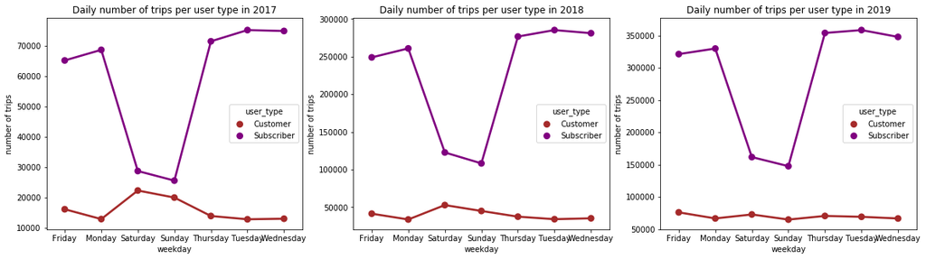

```python
plt.figure(figsize = [20, 5])
colors = {'Subscriber':'purple', 'Customer':'brown'}

plt.subplot(1,3,1)
sb.pointplot(x='start_day', y=0, hue='user_type', scale=.99, palette=colors, data=type_per_day_17)
plt.ylabel('number of trips')
plt.xlabel('weekday')
plt.title('Daily number of trips per user type in 2017')

plt.subplot(1,3,2)
sb.pointplot(x='start_day', y=0, hue='user_type', scale=.99, palette=colors, data=type_per_day_18)
plt.ylabel('number of trips')
plt.xlabel('weekday')
plt.title('Daily number of trips per user type in 2018')

plt.subplot(1,3,3)
sb.pointplot(x='start_day', y=0, hue='user_type', scale=.99, palette=colors, data=type_per_day_19)
plt.ylabel('number of trips')
plt.xlabel('weekday')
plt.title('Daily number of trips per user type in 2019');
```

This line plot represent the daily number of trips for each user type. the subscriber curve shows steep decrease in trips counts in weekend days, while the customer curve showes steady curve with slight increase in weekend( Saturday, Sunday). this appears more in the years 17/18.

## 8-Trip duration per station

[figure not shown]

```python
plt.figure(figsize = [20, 15])

plt.subplot(3,1,1)
base_color=sb.color_palette()[6]
sb.barplot(data = df_17, x= 'duration_min', y='start_station_name', order=station_order, color=base_color)
plt.title('Trip duration per station in 2017');

plt.subplot(3,1,2)
base_color=sb.color_palette()[6]
sb.barplot(data = df_18, x = 'duration_min', y='start_station_name', order=station_order, color=base_color)
plt.title('Trip duration per station in 2018');

plt.subplot(3,1,3)
base_color=sb.color_palette()[6]
sb.barplot(data = df_19, x = 'duration_min', y='start_station_name', order=station_order, color=base_color)
plt.title('Trip duration per station in 2019')
plt.tight_layout(pad=2.0);
```

Here i am checking if there is a relationship between trip duration and starting stations. we can see from the plot of three years are semilar whereas the top two station have the longest trips duration compared to the rest of the station these are (San Francisco Ferry Building (Harry Bridges Plaza) and The Embarcadero at Sansome St). it could be related to stations working hours.

### Talk about some of the relationships you observed in this part of the investigation. How did the feature(s) of interest vary with other features in the dataset?

> - The relationship between number of trip taken by users(subscribers and customers) daily during the week. it was showen that subscribers trips drop during the weekend while customers have steady patteren of trip count through the week.
> - Trip duration for each type of users showed that customers have longer trip duration than subscribers.
> - also figure 8, shows the relationship between stations and trip duration. it showed that two stations users spend more time in their trips when they start their journy from.

### Did you observe any interesting relationships between the other features (not the main feature(s) of interest)?

> The differences in the useres behavior in term of trip duration and the chosen stations and time of the trip during the week

# Multivariate Exploration

> Create plots of three or more variables to investigate your data even further. Make sure that your investigations are justified, and follow from your work in the previous sections.

## 9-Daily trip duration according to user type

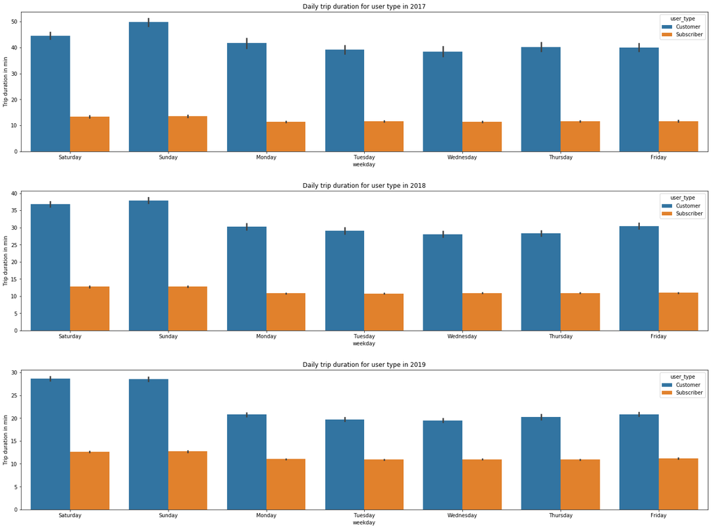

```python
#for multiv do the same insted of count use duration(three variable user type, duration, start day)
plt.figure(figsize = [20, 15])


plt.subplot(3,1,1)
day_order=["Saturday", "Sunday", "Monday", "Tuesday", "Wednesday", "Thursday", "Friday"]
sb.barplot(data = df_17, x = 'start_day', y = 'duration_min', hue = 'user_type', order=day_order, hue_order=['Customer','Subscriber'])
plt.xlabel('weekday')
plt.ylabel('Trip duration in min')
plt.title('Daily trip duration for user type in 2017')

plt.subplot(3,1,2)
sb.barplot(data = df_18, x = 'start_day', y = 'duration_min', hue = 'user_type', order=day_order, hue_order=['Customer','Subscriber'])
plt.xlabel('weekday')
plt.ylabel('Trip duration in min')
plt.title('Daily trip duration for user type in 2018')

plt.subplot(3,1,3)
sb.barplot(data = df_19, x = 'start_day', y = 'duration_min', hue = 'user_type', order=day_order, hue_order=['Customer','Subscriber'])
plt.xlabel('weekday')
plt.ylabel('Trip duration in min')
plt.title('Daily trip duration for user type in 2019')
plt.tight_layout(pad=3.0)
```

from previuse charts we know that the customer trip time is longer than the subscribers. in term of the daily trip duration, with subscriber trip duration shows steady pattren thrugh the week days, while in costomer, tend to increase trip duration during the weekend (Saturday and Sunday) and steady in the rest of week day.

## 10-Monthly trip duration according to user type

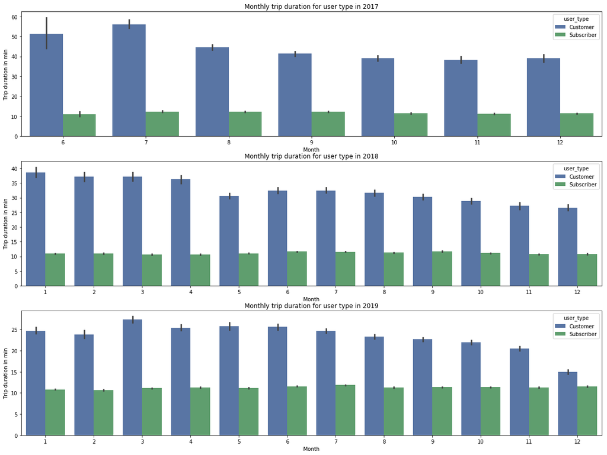

```python
plt.figure(figsize = [20, 15])

plt.subplot(3,1,1)
sb.barplot(data = df_17, y = 'duration_min', x = 'month', hue = 'user_type', hue_order=['Customer','Subscriber'], palette="deep")
plt.xlabel('Month')
plt.ylabel('Trip duration in min')
plt.title('Monthly trip duration for user type in 2017')

plt.subplot(3,1,2)
sb.barplot(data = df_18, y = 'duration_min', x = 'month', hue = 'user_type', hue_order=['Customer','Subscriber'], palette="deep")
plt.xlabel('Month')
plt.ylabel('Trip duration in min')
plt.title('Monthly trip duration for user type in 2018')

plt.subplot(3,1,3)
sb.barplot(data = df_19, y = 'duration_min', x = 'month', hue = 'user_type', hue_order=['Customer','Subscriber'], palette="deep")
plt.xlabel('Month')
plt.ylabel('Trip duration in min')
plt.title('Monthly trip duration for user type in 2019');
```

## 11-Trip duration spent by user type per stations

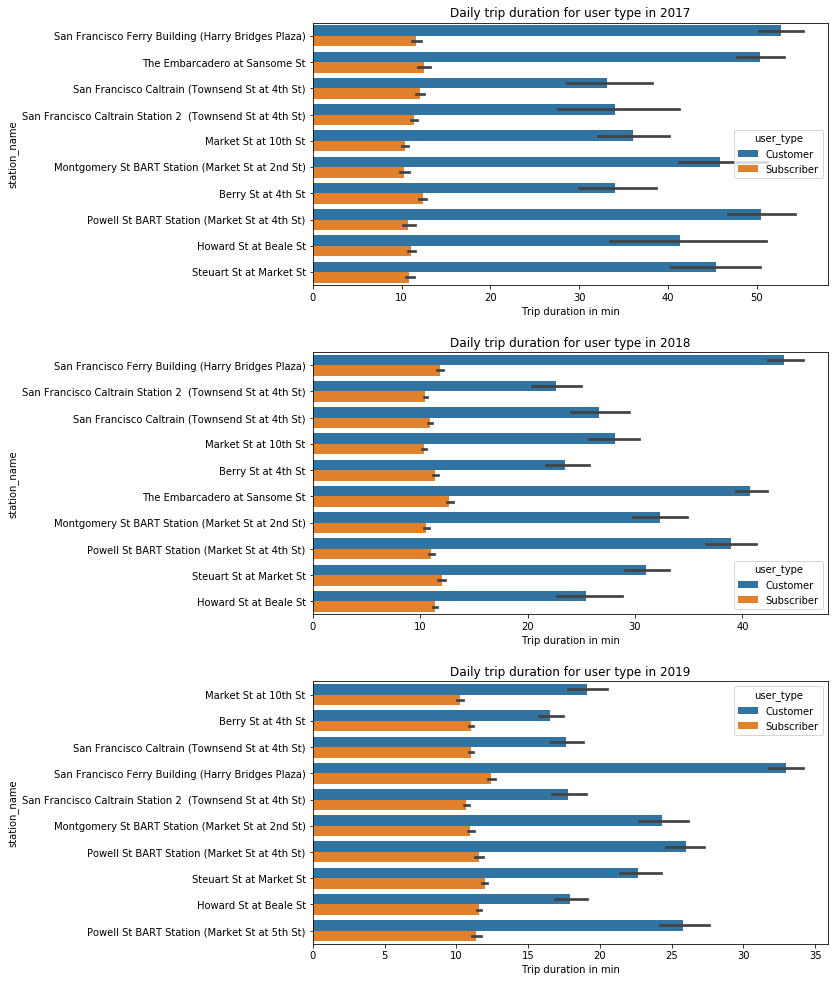

```python
plt.figure(figsize = [12, 14])


plt.subplot(3,1,1)
station_order=top_10_station_17.index
sb.barplot(data = df_17, y = 'start_station_name', x = 'duration_min', hue = 'user_type',hue_order=['Customer','Subscriber'], order=station_order)
plt.ylabel('station_name')
plt.xlabel('Trip duration in min')
plt.title('Daily trip duration for user type in 2017')

plt.subplot(3,1,2)
station_order=top_10_station_18.index
sb.barplot(data = df_18, y = 'start_station_name', x = 'duration_min', hue = 'user_type', hue_order=['Customer','Subscriber'], order=station_order)
plt.ylabel('station_name')
plt.xlabel('Trip duration in min')
plt.title('Daily trip duration for user type in 2018')

station_order=top_10_station_19.index
plt.subplot(3,1,3)
sb.barplot(data = df_19, y = 'start_station_name', x = 'duration_min', hue = 'user_type', hue_order=['Customer','Subscriber'], order=station_order)
plt.ylabel('station_name')
plt.xlabel('Trip duration in min')
plt.title('Daily trip duration for user type in 2019')
plt.tight_layout(pad=2.0);
```

previously I have investigated the relationship between trip duration and station. these charts represent the same previouse one but with specifying user type. In subscribers, trip duration is not affected by different stations. customers trip duration have variation depending on the station. customers spend longer time in their trips in San Francisco Ferry Building (Harry Bridges Plaza) in all years .

### Were there any interesting or surprising interactions between features?

> - daily trip duration according to user type
> - Trip duration spent by user type per stations

> At the end of your report, make sure that you export the notebook as an html file from the `File > Download as... > HTML` menu. Make sure you keep track of where the exported file goes, so you can put it in the same folder as this notebook for project submission. Also, make sure you remove all of the quote-formatted guide notes like this one before you finish your report!